# Homework 4

6210422036 Tanat Iempreedee

```r
library(ggplot2)
library(fpp2)
library(forecast)

data <- read.table("c3p11.csv", header=TRUE, sep = ',', fileEncoding = 'UTF-8-BOM')
data
```

| Date | Sales |
| --- | --- |
| 2-Jan | 6910 |
| 2-Feb | 6959 |
| 2-Mar | 7268 |
| 2-Apr | 7023 |
| 2-May | 7555 |
| 2-Jun | 7021 |
| 2-Jul | 7297 |
| 2-Aug | 7558 |
| 2-Sep | 6945 |
| 2-Oct | 7464 |

[output cut: 158 more lines]

## Creating Time-series

```r
y <- ts(data$Sales, frequency=12, start=c(2002,1))
y
```

```
       Jan   Feb   Mar   Apr   May   Jun   Jul   Aug   Sep
2002  6910  6959  7268  7023  7555  7021  7297  7558  6945
2003  6854  6699  7324  7514  7898  7814  8049  8322  7730
2004  6998  7275  8177  8143  8364  8292  8689  8661  8080
2005  7507  7341  8243  8269  8615  8549  8902  9035  8271
2006  7532  7943  8685  8502  8977  8716  8978  9548  8675
2007  8688  8640  9592  9332  9976  9460 10071 10517  9539
2008  9147  9114  9972  9825 10423 10203 10458 10541  9844
2009  9583  9515 10385 10571 10792 10553 11083 10939 10297
2010 10092 10532 11464 11240 11393 11332 11752 11581 11257
2011 10726 10691 11919 11312 12002 12191 12374 12797 11292
2012 11520 11414 12696 12140 12857 12685 12873 13357 11743
2013 11811 11523 12957 12423 13741 13250 13673 14329 12465
2014 12953 12926 13709 13324 14042 13669 14572 14149 13268
2015 13202 13260 14359 14368 14687 14445 15142 14905 13982
       Oct   Nov   Dec
2002  7464  7138  7355
2003  8049  7449  7774
2004  8264  7822  8352
2005  8328  7987  8383
2006  9032  9005  8921
2007  9850  9227  9699
2008 10455  9715 10338
2009 11056 10229 10703
2010 11447 10742 11372
2011 11523 11259 12596
2012 12129 12003 12794
2013 13026 12606 13281
2014 13918 12992 14312
2015 14575 13838 15478
```

# A.

Plot the data to examine the possible existence of trend and seasonality in the data.

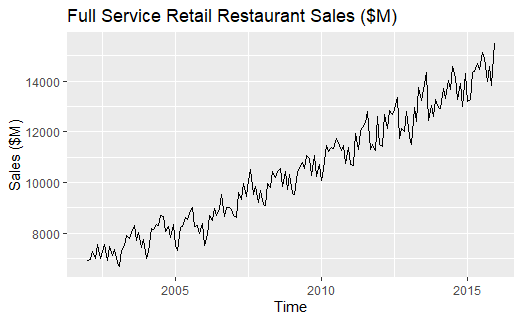

```r
autoplot(y) + ylab('Sales ($M)') + ggtitle('Full Service Retail Restaurant Sales ($M)')
```

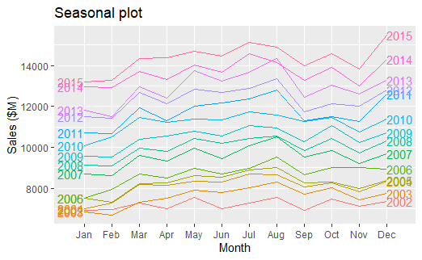

```r
ggseasonplot(y, year.labels = TRUE, year.labels.left = TRUE) +
  ylab("Sales ($M)") +
  ggtitle("Seasonal plot")
```

- **Trend:** Yes, seems like linear.
- **Seasonal:** Yes, A or M? We’ll find out.

## B.

Forecast using the 8 models below  
1. Simple exponential smoothing  
2. Holt’s linear trend  
3. Damped trend  
4. Holt-Winters’ additive seasonal  
5. Holt-Winters’ multiplicative seasonl 6. Winters’ additive seasonal with damped trend  
7. ETS (ZZZ)  
8. ETS (ZZZ, Damped=FALSE)

### Train/Test split

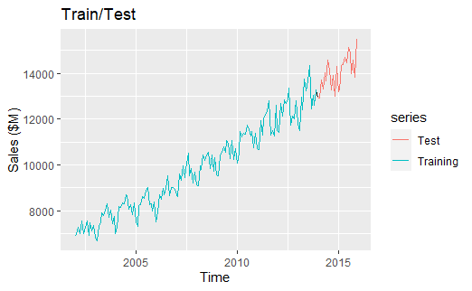

```r
ytrain <- window(y, start=c(2002,1), end=c(2013,12)) # train
ytest <- window(y, start=c(2014,1), end=c(2015,12)) # test
autoplot(y) +
  autolayer(ytrain, series="Training") +
  autolayer(ytest, series="Test") +
  ylab("Sales ($M)") + ggtitle('Train/Test')
```

### 1) SES

```r
ySES <- ses(ytrain, h=24)
accuracy(ySES, ytest)
```

```
                   ME      RMSE      MAE       MPE     MAPE
Training set  87.1472  518.6815 429.7990 0.6951313 4.358694
Test set     937.4963 1168.7766 964.6535 6.4635491 6.673254
                  MASE        ACF1 Theil's U
Training set 0.8195636 -0.06582382        NA
Test set     1.8394526  0.26999035  1.505905
```

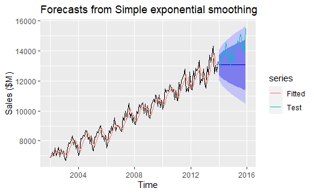

```r
autoplot(ySES) +
  autolayer(fitted(ySES), series="Fitted") +
  autolayer(ytest, series='Test') +
  ylab("Sales ($M)")
```

### 2) Holt’s

```r
yHolt <- holt(ytrain, h=24)
accuracy(yHolt, ytest)
```

```
                    ME     RMSE      MAE      MPE     MAPE
Training set  46.29844 496.8328 412.5034 0.359690 4.210372
Test set     184.08617 577.7300 513.2736 1.143772 3.629007
                  MASE        ACF1 Theil's U
Training set 0.7865834  0.28087634        NA
Test set     0.9787373 -0.02478996 0.7459137
```

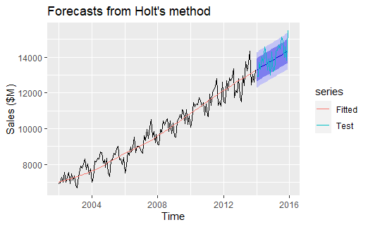

```r
autoplot(yHolt) +
  autolayer(fitted(yHolt), series="Fitted") +
  autolayer(ytest, series='Test') +
  ylab("Sales ($M)")
```

### 3) Damped Holt’s

```r
yHoltDamp <- holt(ytrain, h=24, damped=TRUE)
accuracy(yHoltDamp, ytest)
```

```
                    ME      RMSE      MAE       MPE     MAPE
Training set  65.96131  515.7517 427.5505 0.4317605 4.336342
Test set     908.58483 1140.5660 939.0460 6.2596077 6.494779
                 MASE        ACF1 Theil's U
Training set 0.815276 -0.03847583        NA
Test set     1.790623  0.25710601  1.469783
```

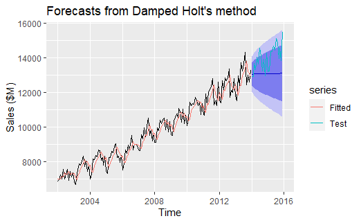

```r
autoplot(yHoltDamp) +
  autolayer(fitted(yHoltDamp), series='Fitted') +
  autolayer(ytest, series='Test') +
  ylab('Sales ($M)')
```

### 4) Holt-Winters’ additive seasonal

```r
yHWA <- hw(ytrain, h=24, seasonal='additive')
accuracy(yHWA, ytest)
```

```
                    ME     RMSE      MAE       MPE     MAPE
Training set  22.82972 236.6312 180.2223 0.1918311 1.861277
Test set     237.96345 372.3669 276.7891 1.6438295 1.938012
                  MASE       ACF1 Theil's U
Training set 0.3436575  0.1244485        NA
Test set     0.5277963 -0.2015974 0.4764224
```

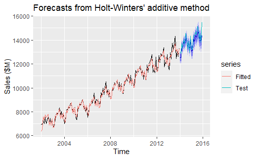

```r
autoplot(yHWA) +
  autolayer(fitted(yHWA), series='Fitted') +
  autolayer(ytest, series='Test') +
  ylab('Sales ($M)')
```

### 5) Holt-Winters’ multiplicative seasonal

```r
yHWM <- hw(ytrain, h=24, seasonal='multiplicative')
accuracy(yHWM, ytest)
```

```
                    ME     RMSE      MAE       MPE     MAPE
Training set  20.10359 212.7085 166.1745 0.1594458 1.737514
Test set     198.21166 355.6316 272.4243 1.4102466 1.936163
                  MASE       ACF1 Theil's U
Training set 0.3168704 0.25293178        NA
Test set     0.5194732 0.02235972 0.4385265
```

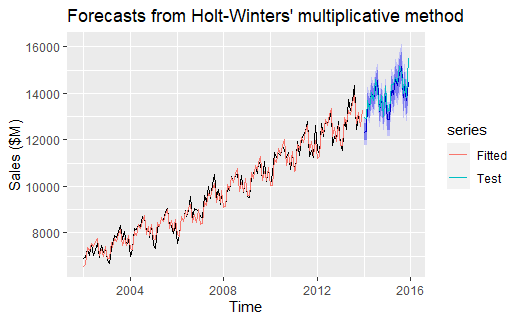

```r
autoplot(yHWM) +
  autolayer(fitted(yHWM), series='Fitted') +
  autolayer(ytest, series='Test') +
  ylab('Sales ($M)')
```

### 6) Damped Holt-Winters’ additive

```r
yHWADamp <- hw(ytrain, h=24, damped=TRUE)
accuracy(yHWADamp,ytest)
```

```
                    ME     RMSE      MAE      MPE     MAPE
Training set  38.66812 247.4422 188.3887 0.345420 1.947398
Test set     517.96540 637.2888 525.9886 3.640165 3.696870
                  MASE       ACF1 Theil's U
Training set 0.3592296 0.08406834        NA
Test set     1.0029830 0.13724701  0.817306
```

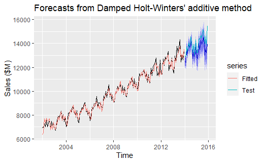

```r
autoplot(yHWADamp) +
  autolayer(fitted(yHWADamp), series='Fitted') +
  autolayer(ytest, series='Test') +
  ylab('Sales ($M)')
```

### 6) ETS (ZZZ)

```r
model1 <- ets(ytrain, "ZZZ")
summary(model1)
```

```
ETS(M,Ad,M)

Call:
 ets(y = ytrain, model = "ZZZ")

  Smoothing parameters:
    alpha = 0.4629
    beta  = 0.0139
    gamma = 1e-04
    phi   = 0.98

  Initial states:
    l = 7013.6146
    b = 42.6606
    s = 1.0065 0.9588 1.0084 0.9741 1.0677 1.0464
           1.0166 1.044 0.9963 1.0187 0.9307 0.9318

  sigma:  0.0237

     AIC     AICc      BIC
2297.271 2302.743 2350.727

Training set error measures:
                   ME     RMSE      MAE       MPE     MAPE
Training set 33.53538 218.3223 170.9087 0.2852867 1.757482
                  MASE       ACF1
Training set 0.3258978 0.02766274
```

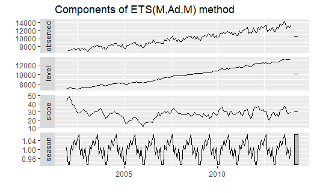

```r
autoplot(model1)
```

```
    Ljung-Box test

data:  Residuals from ETS(M,Ad,M)
Q* = 55.37, df = 7, p-value = 1.259e-09

Model df: 17.   Total lags used: 24
```

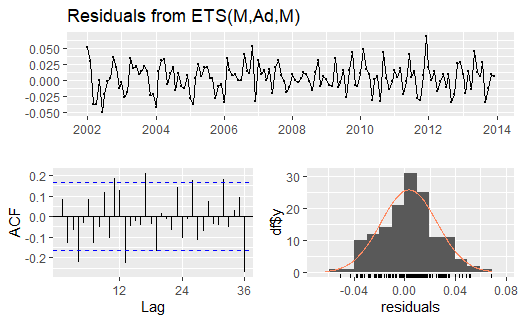

```r
checkresiduals(model1)
```

```r
m1pred <- forecast(model1, h=24)
accuracy(m1pred, ytest)
```

```
                    ME     RMSE      MAE       MPE     MAPE
Training set  33.53538 218.3223 170.9087 0.2852867 1.757482
Test set     534.66116 645.0745 545.1344 3.7685898 3.842611
                  MASE       ACF1 Theil's U
Training set 0.3258978 0.02766274        NA
Test set     1.0394912 0.26186440 0.8221587
```

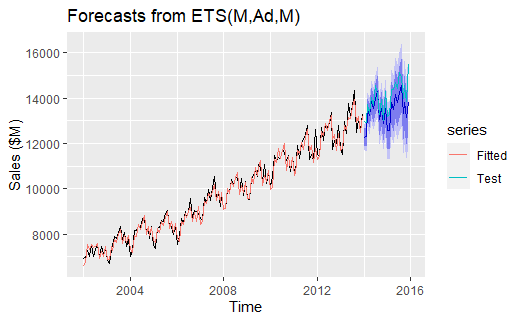

```r
autoplot(m1pred) +
  autolayer(fitted(m1pred), series='Fitted') +
  autolayer(ytest, series='Test') +
  ylab('Sales ($M)')
```

### 7) ETS (ZZZ, Damped=FALSE)

```r
model2 <- ets(ytrain, "ZZZ", damped=FALSE)
summary(model2)
```

```
ETS(M,A,M)

Call:
 ets(y = ytrain, model = "ZZZ", damped = FALSE)

  Smoothing parameters:
    alpha = 0.1423
    beta  = 0.0076
    gamma = 1e-04

  Initial states:
    l = 7013.8255
    b = 32.7678
    s = 1.0018 0.9544 1.0045 0.9718 1.0696 1.0559
           1.0144 1.0474 0.997 1.019 0.93 0.9343

  sigma:  0.0242

     AIC     AICc      BIC
2303.376 2308.233 2353.863

Training set error measures:
                   ME    RMSE     MAE       MPE     MAPE
Training set 15.61505 217.267 168.655 0.1156047 1.754909
                  MASE      ACF1
Training set 0.3216003 0.2589017
```

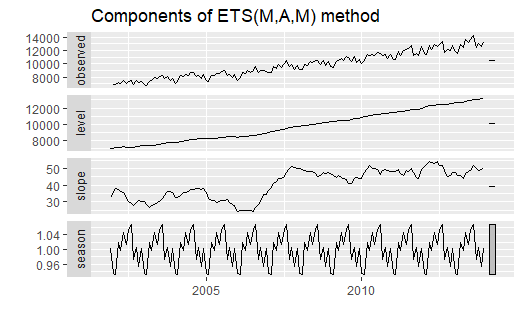

```r
autoplot(model2)
```

```
    Ljung-Box test

data:  Residuals from ETS(M,A,M)
Q* = 61.38, df = 8, p-value = 2.498e-10

Model df: 16.   Total lags used: 24
```

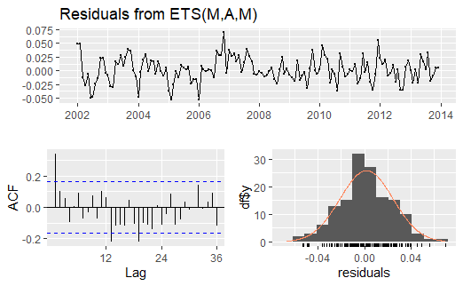

```r
checkresiduals(model2)
```

```r
m2pred <- forecast(model2, h=24)
accuracy(m2pred, ytest)
```

```
                    ME     RMSE      MAE       MPE     MAPE
Training set  15.61505 217.2670 168.6550 0.1156047 1.754909
Test set     177.15926 345.5556 255.5099 1.2592523 1.812794
                  MASE       ACF1 Theil's U
Training set 0.3216003 0.25890167        NA
Test set     0.4872198 0.06481706 0.4297349
```

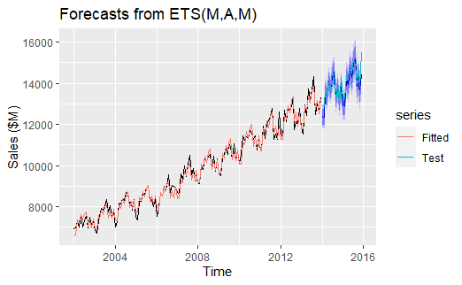

```r
autoplot(m2pred) +
  autolayer(fitted(m2pred), series='Fitted') +
  autolayer(ytest, series='Test') +
  ylab('Sales ($M)')
```

## c. Model Comparison

Comparing MAPE of Train & Test for each model.

```r
metrics <- rbind(accuracy(ySES,ytest)[9:10],
                accuracy(yHolt,ytest)[9:10],
                accuracy(yHWA,ytest)[9:10],
                accuracy(yHoltDamp,ytest)[9:10],
                accuracy(yHWADamp,ytest)[9:10],
                accuracy(m1pred,ytest)[9:10],
                accuracy(m2pred,ytest)[9:10],
                accuracy(yHWM,ytest)[9:10])
metrics <- data.frame(metrics)
colnames(metrics) <- c("Train","Test")
rownames(metrics) <- c("SES","Holt","HW additive","Damped Holt","Damped HW additive", "ETS (M,Ad,M)","ETS (M,A,M)","HW multiplicative")
metrics[order(metrics$Test),]
```

|  | Train | Test |
| --- | --- | --- |
| ETS (M,A,M) | 1.754909 | 1.812794 |
| HW multiplicative | 1.737514 | 1.936163 |
| HW additive | 1.861277 | 1.938012 |
| Holt | 4.210372 | 3.629007 |
| Damped HW additive | 1.947398 | 3.696870 |
| ETS (M,Ad,M) | 1.757482 | 3.842611 |
| Damped Holt | 4.336342 | 6.494779 |
| SES | 4.358694 | 6.673254 |

### Summary

- **ETS(M,A,M)** as a result from ZZZ and Damped=FALSE parameters gives the lowest MAPE on Test set -> **[SELECTED]**
- ETS(M,Ad,M) is from using ZZZ option. Even though its AICc = 2302.743 is lower compared to 2308.233 from ETS(M,A,M), its MAPE loses against many competitors here.
- Trend seems to be linear as the Damped models yield lower performance compared to other linear trend models.
- Seasonal seems to align with multiplicative more by looking at the top 2 scorers.